# Intelligent Systems Final Project

Daniel Izaguirre

November 30, 2016

# Final Project - Decision Trees and Machine Learning in R

What factors are the best predictors for different salaries. Where salaries can be defined by ‘high’, ‘medium’, ‘low’.

## The Dataset

Cleaning the dataset.

```r
hr <- read.csv("HR_comma_sep.csv")
hr$left <- NULL
hr$type <- hr$sales
hr$sales <- NULL

View(head(hr))
length <- nrow(hr)
```

The total tize of the dataset if 14999 observations.

## Decision Tree on the data (original)

### Partitioning

Partition the dataset to into training data and test data.

- Rule in training data: your training data and test data cannot have any common observations.

```r
set.seed(3792)
inTraining <- createDataPartition(y=hr$salary, p=0.6, list=FALSE)
trainingData <- hr[inTraining,]
testData <- hr[-inTraining,]
```

Now that the data is processed into training and test data. The Decision Tree model can be created.

```r
hrModel <- train(salary~., data=trainingData, method="rpart")
hrModel
```

```
## CART
##
## 9001 samples
##    8 predictor
##    3 classes: 'high', 'low', 'medium'
##
## No pre-processing
## Resampling: Bootstrapped (25 reps)
## Summary of sample sizes: 9001, 9001, 9001, 9001, 9001, 9001, ...
## Resampling results across tuning parameters:
##
##   cp           Accuracy   Kappa
##   0.003903709  0.4897016  0.04312682
##   0.004771199  0.4876124  0.04102605
##   0.005638690  0.4883865  0.03759326
##
## Accuracy was used to select the optimal model using  the largest value.
## The final value used for the model was cp = 0.003903709.
```

### The Decision Tree

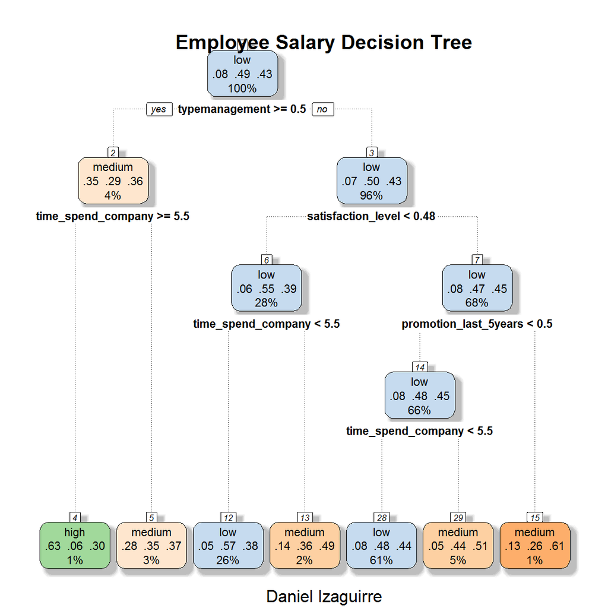

```r
fancyRpartPlot(hrModel$finalModel, main="Employee Salary Decision Tree", sub="Daniel Izaguirre")
```

### Evaluation

Now, the model can be evaluated with the training and test data that has been partition from the original set.

#### In-Sample

```r
trainPrediction <- predict(hrModel, trainingData)
acc_table <- confusionMatrix(trainPrediction, trainingData$salary)$table
acc_table
```

```
##           Reference
## Prediction high  low medium
##     high     50    5     24
##     low     542 3963   3313
##     medium  151  422    531
```

```r
overall <- confusionMatrix(trainPrediction, trainingData$salary)$overall[1]
overall <- round(overall*100, 1)
```

The overall accuracy of the model is 50.5%, when tested against the training data.

#### Out-of-Sample

```r
testPrediction <- predict(hrModel, testData)
acc_table <- confusionMatrix(testPrediction,testData$salary)$table.
acc_table
```

[output not shown]

```r
overall <- confusionMatrix(testPrediction,testData$salary)$overall[1]
overall <- round(overall*100, 1)
```

The overall accuracy of the model is 50.8%, when tested against the testing data.

## Decision Tree on the data (reclassified)

The data which was provided only provided a moderate amount of accuracy. This can be improved by generalizing the data in the dataset more.

I have chosen to focus on the factors which produce a high salary. This has been done by reclassifying the salary variable into ‘high’ and ‘average and low’.

```r
hr <- read.csv("HR_comma_sep.csv")
salary_classifier <- function(n){
    if (n == 'high')
      return("high")
    else if(n == 'medium' || n == 'low')
      return("average and low")
  }
hr$salary <- sapply(hr$salary, salary_classifier)
hr$left <- NULL
hr$type <- hr$sales
hr$sales <- NULL
View(head(hr))
```

### Partitioning

```r
set.seed(3792)
inTraining <- createDataPartition(y=hr$salary, p=0.6, list=FALSE)
trainingData <- hr[inTraining,]
testData <- hr[-inTraining,]

hrModel <- train(salary~., data=trainingData, method="rpart")
hrModel
```

```
## CART
##
## 9001 samples
##    8 predictor
##    2 classes: 'average and low', 'high'
##
## No pre-processing
## Resampling: Bootstrapped (25 reps)
## Summary of sample sizes: 9001, 9001, 9001, 9001, 9001, 9001, ...
## Resampling results across tuning parameters:
##
##   cp           Accuracy   Kappa
##   0.003364738  0.9203907  0.14391536
##   0.005383580  0.9199757  0.12296245
##   0.019515478  0.9183807  0.02830279
##
## Accuracy was used to select the optimal model using  the largest value.
## The final value used for the model was cp = 0.003364738.
```

### The Decision Tree

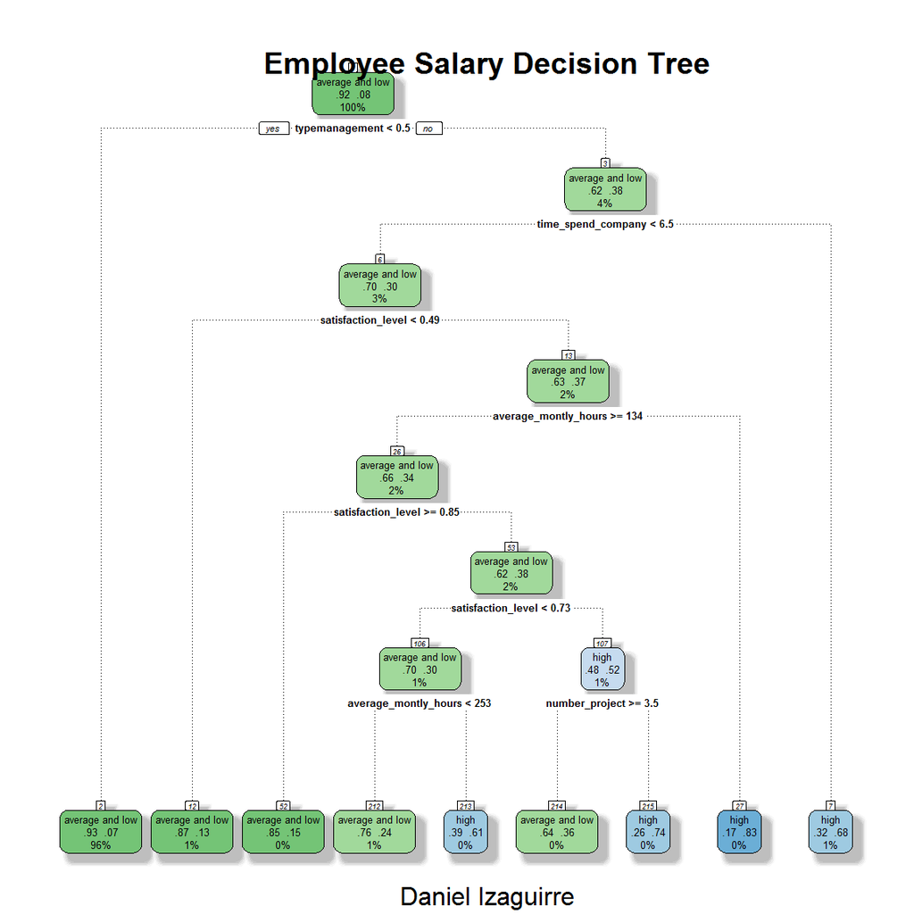

```r
fancyRpartPlot(hrModel$finalModel, main="Employee Salary Decision Tree", sub="Daniel Izaguirre")
```

### Evaluation

Now, the model can be evaluated with the training and test data that has been partition from the reclassified set.

##### In-sample

```r
trainPrediction <- predict(hrModel, trainingData)
acc_table <- confusionMatrix(trainPrediction, trainingData$salary)$table
acc_table
```

```
##                  Reference
## Prediction        average and low high
##   average and low            8217  648
##   high                         41   95
```

```r
overall <- confusionMatrix(trainPrediction, trainingData$salary)$overall[1]
overall <- round(overall*100, 1)
```

The overall accuracy of the model is 92.3%, when tested against the training data.

##### Out-of-Sample

```r
testPrediction <- predict(hrModel, testData)
acc_table <- confusionMatrix(testPrediction,testData$salary)$table
acc_table
```

```
##                  Reference
## Prediction        average and low high
##   average and low            5475  451
##   high                         29   43
```

```r
overall <- confusionMatrix(testPrediction,testData$salary)$overall[1]
overall <- round(overall*100, 1)
```

The overall accuracy of the model is 92%, when tested against the testing data.

The Random Forest algorithm is a machine learning algorithm which can be used to provide a higher accuracy. However it is slow, is resource intensive on your machine, can be difficult to understand (random draws add complexity), and could overfit. Despite the cons, this algorithm is very strong.

```r
hr <- read.csv("HR_comma_sep.csv")
hr$left <- NULL
hr$type <- hr$sales
hr$sales <- NULL
```

### Partitioning

```r
hr <- read.csv("HR_comma_sep.csv")
salary_classifier <- function(n){
    if (n == 'high')
      return("high")
    else if(n == 'medium' || n == 'low')
      return("average and low")
  }
hr$salary <- sapply(hr$salary, salary_classifier)
hr$left <- NULL
hr$type <- hr$sales
hr$sales <- NULL

set.seed(3792)
inTraining <- createDataPartition(y=hr$salary, p=0.4, list=FALSE)
trainingData <- hr[inTraining,]
testData <- hr[-inTraining,]
```

### Random Forest Algorithm

```r
hrModel_rf <- train(salary~., data = trainingData, method = "rf", prox=TRUE)
hrModel_rf
```

```
## Random Forest
##
## 6000 samples
##    8 predictor
##    2 classes: 'average and low', 'high'
##
## No pre-processing
## Resampling: Bootstrapped (25 reps)
## Summary of sample sizes: 6000, 6000, 6000, 6000, 6000, 6000, ...
## Resampling results across tuning parameters:
##
##   mtry  Accuracy   Kappa
##    2    0.9195322  0.0330605
##    9    0.9249298  0.2467862
##   16    0.9230134  0.2450850
##
## Accuracy was used to select the optimal model using  the largest value.
## The final value used for the model was mtry = 9.
```

### Evaluation

#### Out-of-Sample

```r
hrModel_rf$finalModel
```

```
##
## Call:
##  randomForest(x = x, y = y, mtry = param$mtry, proximity = TRUE)
##                Type of random forest: classification
##                      Number of trees: 500
## No. of variables tried at each split: 9
##
##         OOB estimate of  error rate: 6.95%
## Confusion matrix:
##                 average and low high class.error
## average and low            5478   27 0.004904632
## high                        390  105 0.787878788
```

```r
testPrediction <- predict(hrModel_rf,testData)
rf_table <- confusionMatrix(testPrediction,testData$salary)$table
rf_table
```

```
##                  Reference
## Prediction        average and low high
##   average and low            8212  606
##   high                         45  136
```

```r
overall <- confusionMatrix(testPrediction,testData$salary)$overall[1]
overall <- round(overall*100, 1)
```

The overall accuracy of the model is 92.8%, when tested against the testing data.